# US Airlines Sentiment Analysis Using Twitter Data

By:

Ujwala Dharanikota

# Introduction:

In modern digital age companies are not following traditional methods of contacting customers by phone, addressing customer grievances when they physically come to your outlet is a thing of the past. One of the most heavily used medium to gauge customer sentiment about a particular brand is social media. Companies are finding ways to use this data available on social media sites to acquiring customers, retaining customers and grow more business.

The idea of the project is to take the Twitter data and analyze what the customers are saying about the US Airline companies and their services on social media and how can they improve their services and grow business based on the twitter feeds.

We are doing analysis on Six Airline companies - United, US Airways, American, Southwest, Delta and Virgin America.

Questions:

1. In which areas of Airline service do customers face maximum issues?
2. Which model best fits our data to predict the sentiment of the tweets?
3. From which part of US more negative tweets are coming and the corresponding nearest airports to them?
4. How airline companies can make use of this analysis to improve their business?

# Dataset:

The Dataset contains 14640 tweets from 7700 users. Twitter data was scraped from February of 2015. The dataset set includes the Attributes - tweet_id, airline_sentiment, airline_sentiment_confidence, negativereason, negativereason_confidence, airline, airline_sentiment_gold, name, negativereason_gold, retweet_count,text, tweet_coord, tweet_created, tweet_location, user_timezone.

# Data Analysis:

```python
# Import All modules needed for the analysis.
import pandas as pd
import numpy as np
from sklearn import datasets, linear_model, svm, metrics
from sklearn.cross_validation import train_test_split
from sklearn.preprocessing import StandardScaler
from matplotlib.colors import ListedColormap
import matplotlib.pyplot as plt
from sklearn.svm import SVC
from sklearn.neighbors import KNeighborsClassifier
import warnings
from sklearn import metrics
%matplotlib inline
```

```python
from ggplot import *

import seaborn as sns
import matplotlib
```

```python
import plotly.tools as tls
tls.set_credentials_file(username='dujwala', api_key='W1d5PlD81cyIS5ug9EZh')
```

```python
import pandas as pd
import numpy as np
import matplotlib.pyplot as plt
import plotly.tools as tls
import plotly.plotly as py
import plotly.graph_objs as go
%pylab inline


def isNaN(num):
    return num != num
```

```python
T_Data = pd.read_csv("C:/Users/Sony/Desktop/tweets.csv") #Reading the dataset from the csv file
```

```python
T_Data.head()
```

|  | tweet_id | airline_sentiment | airline_sentiment_confidence | negativereason | negativereason_confidence | airline | airline_sentiment_gold | name | negativereason_gold | retweet_count | text | tweet_coord | tweet_created | tweet_location | user_timezone |
| --- | --- | --- | --- | --- | --- | --- | --- | --- | --- | --- | --- | --- | --- | --- | --- |
| 0 | 570306133677760513 | neutral | 1.0000 | NaN | NaN | Virgin America | NaN | cairdin | NaN | 0 | @VirginAmerica What @dhepburn said. | NaN | 2015-02-24 11:35:52 -0800 | NaN | Eastern Time (US & Canada) |
| 1 | 570301130888122368 | positive | 0.3486 | NaN | 0.0000 | Virgin America | NaN | jnardino | NaN | 0 | @VirginAmerica plus you've added commercials t... | NaN | 2015-02-24 11:15:59 -0800 | NaN | Pacific Time (US & Canada) |
| 2 | 570301083672813571 | neutral | 0.6837 | NaN | NaN | Virgin America | NaN | yvonnalynn | NaN | 0 | @VirginAmerica I didn't today... Must mean I n... | NaN | 2015-02-24 11:15:48 -0800 | Lets Play | Central Time (US & Canada) |
| 3 | 570301031407624196 | negative | 1.0000 | Bad Flight | 0.7033 | Virgin America | NaN | jnardino | NaN | 0 | @VirginAmerica it's really aggressive to blast... | NaN | 2015-02-24 11:15:36 -0800 | NaN | Pacific Time (US & Canada) |
| 4 | 570300817074462722 | negative | 1.0000 | Can't Tell | 1.0000 | Virgin America | NaN | jnardino | NaN | 0 | @VirginAmerica and it's a really big bad thing... | NaN | 2015-02-24 11:14:45 -0800 | NaN | Pacific Time (US & Canada) |

```python
T_Data.shape
```

```
(14640, 15)
```

The dataset contains 14640 tweets and 15 variables (columns).

Data cleaning as we can see there are many NaN's in the columns airline_sentiment_gold, negativereason_gold and these columns are not required for our analysis

```python
(len(T_Data)-T_Data.count())/len(T_Data)
```

```
tweet_id                        0.000000
airline_sentiment               0.000000
airline_sentiment_confidence    0.000000
negativereason                  0.373087
negativereason_confidence       0.281284
airline                         0.000000
airline_sentiment_gold          0.997268
name                            0.000000
negativereason_gold             0.997814
retweet_count                   0.000000
text                            0.000000
tweet_coord                     0.930396
tweet_created                   0.000000
tweet_location                  0.323292
user_timezone                   0.329235
dtype: float64
```

```python
del T_Data['airline_sentiment_gold']
del T_Data['negativereason_gold']
```

```python
T_Data.shape
```

```
(14640, 13)
```

# Proportion of tweets with each sentiment

```python
prop_data = T_Data['airline_sentiment'].value_counts()
prop_data
```

```
negative    9178
neutral     3099
positive    2363
Name: airline_sentiment, dtype: int64
```

```python
prop_data/prop_data.sum()
```

```
negative    0.626913
neutral     0.211680
positive    0.161407
Name: airline_sentiment, dtype: float64
```

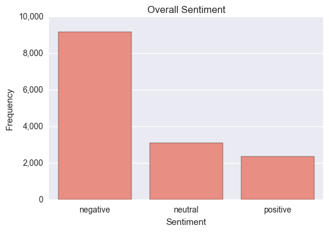

```python
s = pd.value_counts(T_Data['airline_sentiment']).to_frame().reset_index()
s.columns = ['type', 'count']

def air_graph(graph_title):

    sns.set_style("darkgrid")
    ax = sns.barplot(y = "count", x = 'type', color='salmon' ,data=s)
    ax.set(xlabel = 'Sentiment', ylabel = 'Frequency', title = graph_title)
    ax.get_yaxis().set_major_formatter(
    matplotlib.ticker.FuncFormatter(lambda x, p: format(int(x), ',')))
    _ = ax.set_xticklabels(ax.get_xticklabels(), rotation=0)

air_graph('Overall Sentiment')
```

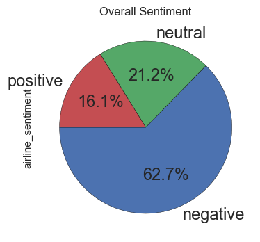

```python
fig = plt.figure(figsize=(4,4), dpi=200)
ax = plt.subplot(111)

prop_data.plot(kind='pie',title = 'Overall Sentiment', ax=ax, autopct='%1.1f%%', startangle=180, fontsize=17)
```

From the above graphs we can see that most of the tweets have negative sentiment

# Proportion of tweets per airline

```python
airline_prop = pd.crosstab(index=T_Data["airline"],columns="count")
airline_prop
```

| col_0 airline | count |
| --- | --- |
| American | 2759 |
| Delta | 2222 |
| Southwest | 2420 |
| US Airways | 2913 |
| United | 3822 |
| Virgin America | 504 |

```python
airline_prop/airline_prop.sum()
```

| col_0 airline | count |
| --- | --- |
| American | 0.188456 |
| Delta | 0.151776 |
| Southwest | 0.165301 |
| US Airways | 0.198975 |
| United | 0.261066 |
| Virgin America | 0.034426 |

```python
airline_prop_data = T_Data['airline'].value_counts()
airline_prop_data = airline_prop_data/airline_prop_data.sum()
airline_prop_data
```

```
United            0.261066
US Airways        0.198975
American          0.188456
Southwest         0.165301
Delta             0.151776
Virgin America    0.034426
Name: airline, dtype: float64
```

Most of the tweets are for United followed by Us Airways, American, Very few tweets are targeted towards Virgin America Lets see this visually

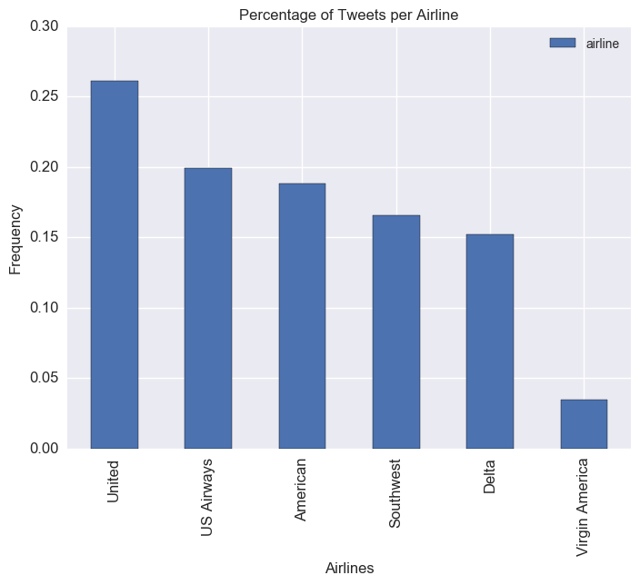

```python
axp = airline_prop_data.plot(kind='bar', title ="Percentage of Tweets per Airline",figsize=(8,6),legend=True, fontsize=12)
axp.set_xlabel("Airlines",fontsize=12)
axp.set_ylabel("Frequency",fontsize=12)
```

# Proportion of sentiment tweets per airline

```python
gby = T_Data.groupby(['airline','airline_sentiment']).count()
gby.tweet_id
```

```
airline         airline_sentiment
American        negative             1960
                neutral               463
                positive              336
Delta           negative              955
                neutral               723
                positive              544
Southwest       negative             1186
                neutral               664
                positive              570
US Airways      negative             2263
                neutral               381
                positive              269
United          negative             2633
                neutral               697
                positive              492
Virgin America  negative              181
                neutral               171
                positive              152
Name: tweet_id, dtype: int64
```

```python
gbar = ggplot(T_Data, aes(x = "airline", y = "Frequency", fill = "airline_sentiment"))
gbar=gbar + geom_bar(stat = 'identity', position = 'fill')
gbar1 = gbar

gbar = ggplot(T_Data, aes(x = "airline", y = "Frequency", fill = "airline_sentiment"))
gbar=gbar + geom_bar(stat = 'identity')
gbar2 = gbar
```

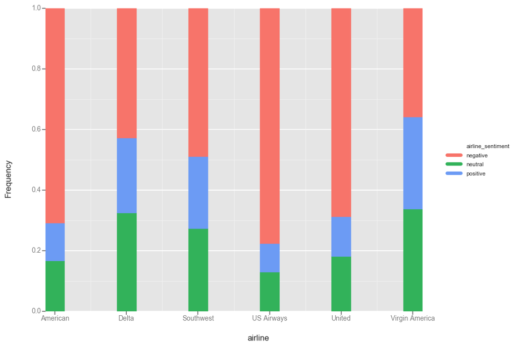

```python
gbar1
```

From the above plots we can find that the distribution of sentiment for American,US Airways and United airlines are always skewed toward negative sentiment. On contrary, the sentiments are distributed more balanced with the other three airline companies.

# 1. In which areas of Airline service do customers face maximum issues?

# Proportion of Negative Reasons for Tweet

Ignoring all the rows which has negative reason as Can't Tell

```python
T_Data_Reason = T_Data[T_Data.negativereason != "Can't Tell"]
T_Data_Reason.head()
```

|  | tweet_id | airline_sentiment | airline_sentiment_confidence | negativereason | negativereason_confidence | airline | name | retweet_count | text | tweet_coord | tweet_created | tweet_location | user_timezone |
| --- | --- | --- | --- | --- | --- | --- | --- | --- | --- | --- | --- | --- | --- |
| 0 | 570306133677760513 | neutral | 1.0000 | NaN | NaN | Virgin America | cairdin | 0 | @VirginAmerica What @dhepburn said. | NaN | 2015-02-24 11:35:52 -0800 | NaN | Eastern Time (US & Canada) |
| 1 | 570301130888122368 | positive | 0.3486 | NaN | 0.0000 | Virgin America | jnardino | 0 | @VirginAmerica plus you've added commercials t... | NaN | 2015-02-24 11:15:59 -0800 | NaN | Pacific Time (US & Canada) |
| 2 | 570301083672813571 | neutral | 0.6837 | NaN | NaN | Virgin America | yvonnalynn | 0 | @VirginAmerica I didn't today... Must mean I n... | NaN | 2015-02-24 11:15:48 -0800 | Lets Play | Central Time (US & Canada) |
| 3 | 570301031407624196 | negative | 1.0000 | Bad Flight | 0.7033 | Virgin America | jnardino | 0 | @VirginAmerica it's really aggressive to blast... | NaN | 2015-02-24 11:15:36 -0800 | NaN | Pacific Time (US & Canada) |
| 6 | 570300616901320704 | positive | 0.6745 | NaN | 0.0000 | Virgin America | cjmcginnis | 0 | @VirginAmerica yes, nearly every time I fly VX... | NaN | 2015-02-24 11:13:57 -0800 | San Francisco CA | Pacific Time (US & Canada) |

```python
NR_Count=dict(T_Data_Reason['negativereason'].value_counts(sort=False))
NR_Count
```

```
{'Bad Flight': 580,
 'Cancelled Flight': 847,
 'Customer Service Issue': 2910,
 'Damaged Luggage': 74,
 'Flight Attendant Complaints': 481,
 'Flight Booking Problems': 529,
 'Late Flight': 1665,
 'Lost Luggage': 724,
 'longlines': 178}
```

Defining functions to count the frequency of each negative reason for each and every Airline

```python
def NR_Count(Airline):
    if Airline=='All':
        df=T_Data_Reason
    else:
        df=T_Data_Reason[T_Data['airline']==Airline]
    count=dict(df['negativereason'].value_counts())
    Unique_reason=list(T_Data_Reason['negativereason'].unique())
    Unique_reason=[x for x in Unique_reason if str(x) != 'nan']
    Reason_frame=pd.DataFrame({'Reasons':Unique_reason})
    Reason_frame['count']=Reason_frame['Reasons'].apply(lambda x: count[x])
    return Reason_frame
```

```python
def plot_reason(Airline):
    df=NR_Count(Airline)
    count=df['count']
    Index = range(1,(len(df)+1))
    plt.bar(Index,count)
    plt.xticks(Index,df['Reasons'],rotation=90)
    plt.ylabel('Count')
    plt.xlabel('Reason')
    plt.title('Count of Reasons for '+Airline)
```

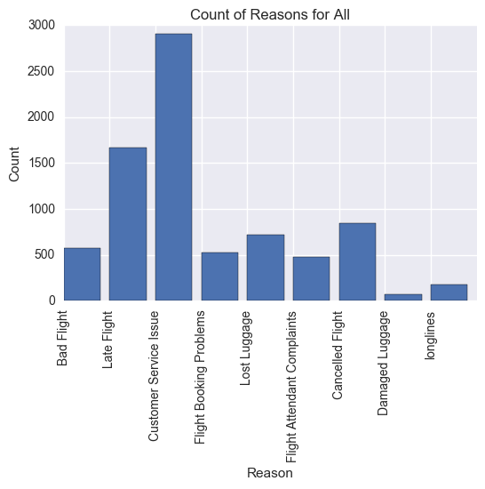

```python
plot_reason('All')
```

From the above analysis we can make a statement that most of the people have complaints on Customer Service Issues

# Plotting frequency of negative reasons for specific airlines

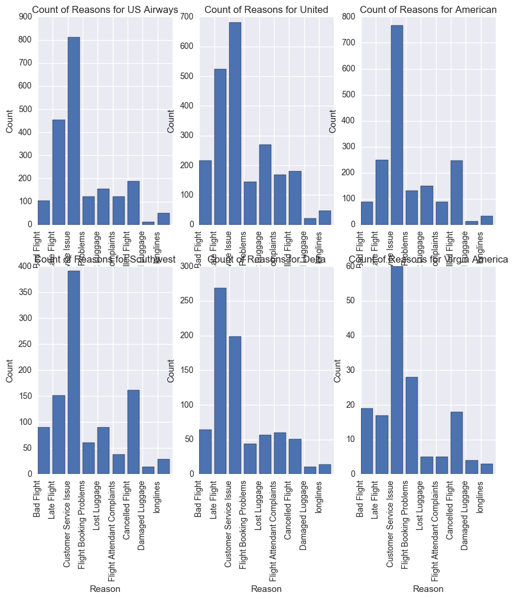

```python
plt.figure(1,figsize=(10, 10))
plt.subplot(231)
plot_reason('US Airways')
plt.subplot(232)
plot_reason('United')
plt.subplot(233)
plot_reason('American')
plt.subplot(234)
plot_reason('Southwest')
plt.subplot(235)
plot_reason('Delta')
plt.subplot(236)
plot_reason('Virgin America')
```

From the above analysis and graphs we could say that:

-> Delta customes faces major isuues with late flight

-> United also faces major issues due to flight delay

# Word Could For the Negative Tweets

```python
from wordcloud import WordCloud,STOPWORDS
```

```python
df=T_Data[T_Data['airline_sentiment']=='negative']
words = ' '.join(df['text'])
cleaned_word = " ".join([word for word in words.split()
                            if 'http' not in word
                                and not word.startswith('@')
                                and word != 'RT'
                            ])
```

```python
wordcloud = WordCloud(stopwords=STOPWORDS,
                      background_color='white',
                      width=3000,
                      height=2500
                     ).generate(cleaned_word)
```

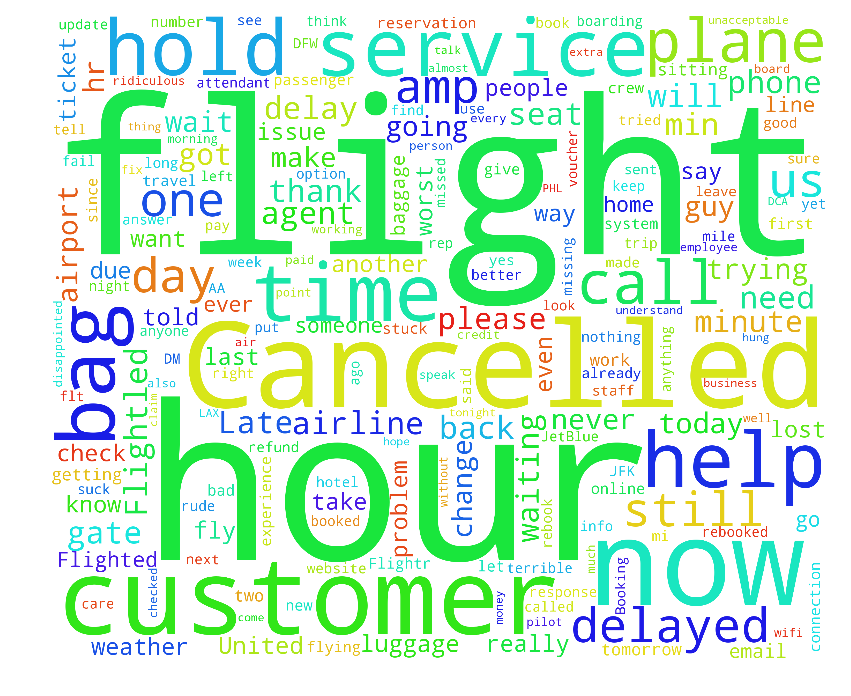

```python
plt.figure(1,figsize=(10, 10))
plt.imshow(wordcloud)
plt.axis('off')
plt.show()
```

We can find that the Tweets with negative sentiment are frequently involved with some words like cancelled, flight ,customer or hour. We can guess that customer tends to complain when they are waiting for the delayed flights and flight cancelled.

# 2. Which model best fits our data to predict the sentiment of the tweets?

# Preprocess the Data and compare the model performances

```python
import re
import nltk
from nltk.corpus import stopwords
```

```python
def tweet_to_words(raw_tweet):
    letters_only = re.sub("[^a-zA-Z]", " ",raw_tweet)
    words = letters_only.lower().split()
    stops = set(stopwords.words("english"))
    meaningful_words = [w for w in words if not w in stops]
    return( " ".join( meaningful_words ))
```

Cleaning the tweet by making a list of stopwords and removing them from the tweet

```python
def clean_tweet_length(raw_tweet):
    letters_only = re.sub("[^a-zA-Z]", " ",raw_tweet)
    words = letters_only.lower().split()
    stops = set(stopwords.words("english"))
    meaningful_words = [w for w in words if not w in stops]
    return(len(meaningful_words))
```

Once the tweet is cleaned finding the lenght of the tweet

```python
T_Data['sentiment']=T_Data['airline_sentiment'].apply(lambda x: 0 if x=='negative' else 1)
```

Creating a new coloumn "sentiment" of type int with 0 and 1 values in the dataset based on airline_sentiment coloumn, "0" repersents negative sentiment.

```python
T_Data['clean_tweet']=T_Data['text'].apply(lambda x: tweet_to_words(x))
T_Data['Tweet_length']=T_Data['text'].apply(lambda x: clean_tweet_length(x))
train,test = train_test_split(T_Data,test_size=0.2,random_state=42)
```

Storing the cleaned tweets and length of the tweets in the new coloumns. Spliting the data into trained data and test data

```python
T_Data.head()
```

|  | tweet_id | airline_sentiment | airline_sentiment_confidence | negativereason | negativereason_confidence | airline | name | retweet_count | text | tweet_coord | tweet_created | tweet_location | user_timezone | sentiment | clean_tweet | Tweet_length |
| --- | --- | --- | --- | --- | --- | --- | --- | --- | --- | --- | --- | --- | --- | --- | --- | --- |
| 0 | 570306133677760513 | neutral | 1.0000 | NaN | NaN | Virgin America | cairdin | 0 | @VirginAmerica What @dhepburn said. | NaN | 2015-02-24 11:35:52 -0800 | NaN | Eastern Time (US & Canada) | 1 | virginamerica dhepburn said | 3 |
| 1 | 570301130888122368 | positive | 0.3486 | NaN | 0.0000 | Virgin America | jnardino | 0 | @VirginAmerica plus you've added commercials t... | NaN | 2015-02-24 11:15:59 -0800 | NaN | Pacific Time (US & Canada) | 1 | virginamerica plus added commercials experienc... | 6 |
| 2 | 570301083672813571 | neutral | 0.6837 | NaN | NaN | Virgin America | yvonnalynn | 0 | @VirginAmerica I didn't today... Must mean I n... | NaN | 2015-02-24 11:15:48 -0800 | Lets Play | Central Time (US & Canada) | 1 | virginamerica today must mean need take anothe... | 8 |
| 3 | 570301031407624196 | negative | 1.0000 | Bad Flight | 0.7033 | Virgin America | jnardino | 0 | @VirginAmerica it's really aggressive to blast... | NaN | 2015-02-24 11:15:36 -0800 | NaN | Pacific Time (US & Canada) | 0 | virginamerica really aggressive blast obnoxiou... | 11 |
| 4 | 570300817074462722 | negative | 1.0000 | Can't Tell | 1.0000 | Virgin America | jnardino | 0 | @VirginAmerica and it's a really big bad thing... | NaN | 2015-02-24 11:14:45 -0800 | NaN | Pacific Time (US & Canada) | 0 | virginamerica really big bad thing | 5 |

Created 3 new coloums sentiment,clean_tweet and tweet_length

```python
nltk.download()
```

```
showing info https://raw.githubusercontent.com/nltk/nltk_data/gh-pages/index.xml
```

```
True
```

```python
train_clean_tweet=[]
for tweet in train['clean_tweet']:
    train_clean_tweet.append(tweet)
test_clean_tweet=[]
for tweet in test['clean_tweet']:
    test_clean_tweet.append(tweet)
```

Creating train data and test data

```python
# Defining/setting the tain features and test features
from sklearn.feature_extraction.text import CountVectorizer
v = CountVectorizer(analyzer = "word")
train_features= v.fit_transform(train_clean_tweet)
test_features=v.transform(test_clean_tweet)
```

```python
test_features
```

```
<2928x11919 sparse matrix of type '<class 'numpy.int64'>'
	with 27301 stored elements in Compressed Sparse Row format>
```

```python
from sklearn.linear_model import LogisticRegression
from sklearn.neighbors import KNeighborsClassifier
from sklearn.svm import SVC, LinearSVC, NuSVC
from sklearn.tree import DecisionTreeClassifier
from sklearn.ensemble import RandomForestClassifier, AdaBoostClassifier, GradientBoostingClassifier
from sklearn.naive_bayes import GaussianNB
from sklearn.discriminant_analysis import LinearDiscriminantAnalysis
from sklearn.discriminant_analysis import QuadraticDiscriminantAnalysis
from sklearn.metrics import accuracy_score
```

```python
Classifiers = [
    LogisticRegression(C=0.000000001,solver='liblinear',max_iter=200),
    KNeighborsClassifier(3),
    SVC(kernel="rbf", C=0.025, probability=True),
    DecisionTreeClassifier(),
    RandomForestClassifier(n_estimators=200),
    AdaBoostClassifier(),
    GaussianNB()]
```

```python
dense_features=train_features.toarray()
dense_test= test_features.toarray()
Accuracy=[]
Model=[]
for classifier in Classifiers:
    try:
        fit = classifier.fit(train_features,train['sentiment'])
        pred = fit.predict(test_features)
    except Exception:
        fit = classifier.fit(dense_features,train['sentiment'])
        pred = fit.predict(dense_test)
    accuracy = accuracy_score(pred,test['sentiment'])
    Accuracy.append(accuracy)
    Model.append(classifier.__class__.__name__)
    print('Accuracy of '+classifier.__class__.__name__+' is '+str(accuracy))
```

```
Accuracy of LogisticRegression is 0.645150273224
Accuracy of KNeighborsClassifier is 0.589139344262
Accuracy of SVC is 0.645150273224
Accuracy of DecisionTreeClassifier is 0.760245901639
Accuracy of RandomForestClassifier is 0.812841530055
Accuracy of AdaBoostClassifier is 0.785519125683
Accuracy of GaussianNB is 0.572404371585
```

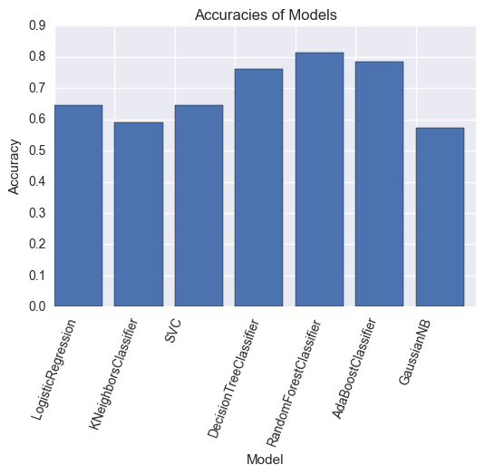

```python
Index = [1,2,3,4,5,6,7]
plt.bar(Index,Accuracy)
plt.xticks(Index, Model,rotation=70)
plt.ylabel('Accuracy')
plt.xlabel('Model')
plt.title('Accuracies of Models')
```

From the above model comparision we can say that RandomForestClassifier with an accuracy of 0.812841530055 best fits our data to clasify our tweets and find/predict the sentiment from the tweet(based on the words in the tweet).

# 3. From which part of US more negative tweets are coming and the corresponding nearest airports to them?

Finding the locations of twitter feed from location data. I imputed 0 for cases where the location information was not available.

```python
T_Data["latitude"] = 0.0
T_Data["longitude"] = 0.0
i = -1
for num in T_Data.tweet_coord:
    i = i+1
    if isNaN(num)==False:
        a = num
        aa = a[1:len(a)-1]
        aa.split(',')
        T_Data["latitude"][i] = float(aa.split(",")[0])
        T_Data["longitude"][i] = float(aa.split(",")[1])

T_Data.head()
```

|  | tweet_id | airline_sentiment | airline_sentiment_confidence | negativereason | negativereason_confidence | airline | name | retweet_count | text | tweet_coord | tweet_created | tweet_location | user_timezone | sentiment | clean_tweet | Tweet_length | latitude | longitude |
| --- | --- | --- | --- | --- | --- | --- | --- | --- | --- | --- | --- | --- | --- | --- | --- | --- | --- | --- |
| 0 | 570306133677760513 | neutral | 1.0000 | NaN | NaN | Virgin America | cairdin | 0 | @VirginAmerica What @dhepburn said. | NaN | 2015-02-24 11:35:52 -0800 | NaN | Eastern Time (US & Canada) | 1 | virginamerica dhepburn said | 3 | 0.0 | 0.0 |
| 1 | 570301130888122368 | positive | 0.3486 | NaN | 0.0000 | Virgin America | jnardino | 0 | @VirginAmerica plus you've added commercials t... | NaN | 2015-02-24 11:15:59 -0800 | NaN | Pacific Time (US & Canada) | 1 | virginamerica plus added commercials experienc... | 6 | 0.0 | 0.0 |
| 2 | 570301083672813571 | neutral | 0.6837 | NaN | NaN | Virgin America | yvonnalynn | 0 | @VirginAmerica I didn't today... Must mean I n... | NaN | 2015-02-24 11:15:48 -0800 | Lets Play | Central Time (US & Canada) | 1 | virginamerica today must mean need take anothe... | 8 | 0.0 | 0.0 |
| 3 | 570301031407624196 | negative | 1.0000 | Bad Flight | 0.7033 | Virgin America | jnardino | 0 | @VirginAmerica it's really aggressive to blast... | NaN | 2015-02-24 11:15:36 -0800 | NaN | Pacific Time (US & Canada) | 0 | virginamerica really aggressive blast obnoxiou... | 11 | 0.0 | 0.0 |
| 4 | 570300817074462722 | negative | 1.0000 | Can't Tell | 1.0000 | Virgin America | jnardino | 0 | @VirginAmerica and it's a really big bad thing... | NaN | 2015-02-24 11:14:45 -0800 | NaN | Pacific Time (US & Canada) | 0 | virginamerica really big bad thing | 5 | 0.0 | 0.0 |

Reading a dataset which contains list of 30 busiest airports in United States and their latitude longitude values

```python
df_airport = pd.read_csv('C:/Users/Sony/Desktop/data_airports.csv')
df_airport.head()
```

|  | airport_id | name | city | State | latitude | longitude |
| --- | --- | --- | --- | --- | --- | --- |
| 0 | 1 | Hartsfield Jackson Atlanta Intl | Atlanta | GA | 33.636719 | -84.428067 |
| 1 | 2 | Los Angeles Intl | Los Angeles | CA | 33.942536 | -118.408075 |
| 2 | 3 | Chicago Ohare Intl | Chicago | IL | 41.978603 | -87.904842 |
| 3 | 4 | Dallas Fort Worth Intl | Dallas-fort Worth | TX | 32.896828 | -97.037997 |
| 4 | 5 | John F Kennedy Intl | New York | NY | 40.639751 | -73.778925 |

Merging information from 2 datasets and assigning each tweet with location data to an airport based on proximity. Assuming that a tweet about an airline came from the airport closest to the location of tweet. Computed distance between tweet location and the closest airport from the top 30 airports, and assign airport for each tweet with location data.

```python
T_Data['airport_name'] = '';
T_Data['airport_city'] = '';
T_Data['airport_state'] = '';
T_Data['airport_lat'] = 0.0;
T_Data['airport_lon'] = 0.0;



for i in range(0,len(T_Data['latitude'])):
    d_all = 0;
    if (T_Data['latitude'][i]!=0):
        d_all = (df_airport['latitude']-T_Data['latitude'][i])**2+(df_airport['longitude']-T_Data['longitude'][i])**2
        ind_min = np.argmin(d_all)
        #print i,df_airport['latitude'][ind_min];
        T_Data['airport_name'][i]=df_airport['name'][ind_min]
        T_Data['airport_city'][i]=df_airport['city'][ind_min]
        T_Data['airport_state'][i]=df_airport['State'][ind_min]
        T_Data['airport_lat'][i] = df_airport['latitude'][ind_min];
        T_Data['airport_lon'][i] = df_airport['longitude'][ind_min];
```

[output not shown]

```python
T_Data.shape
```

```
(14640, 23)
```

Now we have 23 columns in the dataset. Creating a dataframe which contains only these columns which are required for our analysis and imported it into CSV file.

```python
df_T_A = T_Data[['tweet_id',"airline_sentiment","airline","negativereason","latitude","longitude","user_timezone",
              'airport_name','airport_city','airport_state','airport_lat','airport_lon','sentiment']]
df_T_A.to_csv('data_twitter_airport.csv')
df_T_A.head()
```

|  | tweet_id | airline_sentiment | airline | negativereason | latitude | longitude | user_timezone | airport_name | airport_city | airport_state | airport_lat | airport_lon | sentiment |
| --- | --- | --- | --- | --- | --- | --- | --- | --- | --- | --- | --- | --- | --- |
| 0 | 570306133677760513 | neutral | Virgin America | NaN | 0.0 | 0.0 | Eastern Time (US & Canada) |  |  |  | 0.0 | 0.0 | 1 |
| 1 | 570301130888122368 | positive | Virgin America | NaN | 0.0 | 0.0 | Pacific Time (US & Canada) |  |  |  | 0.0 | 0.0 | 1 |
| 2 | 570301083672813571 | neutral | Virgin America | NaN | 0.0 | 0.0 | Central Time (US & Canada) |  |  |  | 0.0 | 0.0 | 1 |
| 3 | 570301031407624196 | negative | Virgin America | Bad Flight | 0.0 | 0.0 | Pacific Time (US & Canada) |  |  |  | 0.0 | 0.0 | 0 |
| 4 | 570300817074462722 | negative | Virgin America | Can't Tell | 0.0 | 0.0 | Pacific Time (US & Canada) |  |  |  | 0.0 | 0.0 | 0 |

```python
df_T_A_Neg = df_T_A
```

```python
df_T_A_Neg[df_T_A_Neg.sentiment == 0].head()  # 0 represents negative sentiment
```

|  | tweet_id | airline_sentiment | airline | negativereason | latitude | longitude | user_timezone | airport_name | airport_city | airport_state | airport_lat | airport_lon | sentiment |
| --- | --- | --- | --- | --- | --- | --- | --- | --- | --- | --- | --- | --- | --- |
| 3 | 570301031407624196 | negative | Virgin America | Bad Flight | 0.0 | 0.0 | Pacific Time (US & Canada) |  |  |  | 0.0 | 0.0 | 0 |
| 4 | 570300817074462722 | negative | Virgin America | Can't Tell | 0.0 | 0.0 | Pacific Time (US & Canada) |  |  |  | 0.0 | 0.0 | 0 |
| 5 | 570300767074181121 | negative | Virgin America | Can't Tell | 0.0 | 0.0 | Pacific Time (US & Canada) |  |  |  | 0.0 | 0.0 | 0 |
| 15 | 570282469121007616 | negative | Virgin America | Late Flight | 0.0 | 0.0 | Pacific Time (US & Canada) |  |  |  | 0.0 | 0.0 | 0 |
| 17 | 570276917301137409 | negative | Virgin America | Bad Flight | 0.0 | 0.0 | Eastern Time (US & Canada) |  |  |  | 0.0 | 0.0 | 0 |

```python
import numpy as np
import pandas as pd
import scipy.stats as st
import matplotlib.pyplot as plt
import seaborn as sns
from bokeh.io import output_file, show
from bokeh.models import GeoJSONDataSource
from bokeh.plotting import figure
from bokeh.sampledata.sample_geojson import geojson

from bokeh.models import ColumnDataSource

geo_source = GeoJSONDataSource(geojson=geojson)

justLatLong = df_T_A_Neg[['latitude', 'longitude','airport_lat','airport_lon']]

source = ColumnDataSource(ColumnDataSource.from_df(data=justLatLong))
print(source)
```

```
ColumnDataSource, ViewModel:ColumnDataSource, ref _id: ea17ae93-c3e7-4841-b72a-939222755118
```

Latitude and longitude values are plotted on google maps - blue dots represents location of the tweets created and red squares represents location of the airports. We can also store the plot in a html file by calling output_file instead of output_notebook.

```python
from bokeh.io import output_notebook, show
from bokeh.models import (
  GMapPlot, GMapOptions, ColumnDataSource, Circle,Square, DataRange1d, PanTool, WheelZoomTool,BoxZoomTool, HoverTool, BoxSelectTool, SaveTool, ResetTool, ResizeTool
)

API_KEY = "AIzaSyCjpDmWKhYu3eR9wnKWnpuFU1UCU-yPXPk"

map_options = GMapOptions(lat= 37.0902, lng=-95.7129, map_type="roadmap", zoom=3)

plot = GMapPlot(
    x_range=DataRange1d(), y_range=DataRange1d(), map_options=map_options, api_key=API_KEY,
)
plot.title.text = "United States of America"

print(source)
circle = Circle(x="longitude", y="latitude", size=7, fill_color="blue", fill_alpha=0.8, line_color=None)
square = Square(x="airport_lon", y="airport_lat", size=10, fill_color="red", fill_alpha=0.8, line_color=None, visible = True)
plot.add_glyph(source, circle)
plot.add_glyph(source, square)


hover = HoverTool(tooltips=[("Airport_Name", "$airport_name"),("Latitude", "$airport_lat"),("Longitude", "$airport_lon"),])


plot.add_tools(PanTool(), WheelZoomTool(), BoxSelectTool(), SaveTool(), ResetTool(), ResizeTool(), BoxZoomTool(), hover)
output_notebook()
show(plot)
```

```
ColumnDataSource, ViewModel:ColumnDataSource, ref _id: ea17ae93-c3e7-4841-b72a-939222755118
```

[interactive chart not shown]

Blue dots represents location where tweet is created and red squares represents location of the Airports.

Tweets appear to be more around big airports, like New York, Chicago, Los Angeles, etc.

Some airports are closely located like JFK, LaGuardia and Newark Liberty its difficult to say which airport customer has used.

```python
T_Data_Reason_Airport = T_Data[T_Data.negativereason != "Can't Tell"]
```

```python
T_Data_Reason_Airport = T_Data_Reason_Airport[T_Data_Reason_Airport.airport_lat != 0.0]
```

```python
T_Data_Reason_Airport = T_Data_Reason_Airport[['tweet_id',"airline","negativereason",'airport_name']]
```

Ignored rows which contains Can't Tell as the negativereason and the rows which does not have airport data

```python
Groupby_Airline_Airport = T_Data_Reason_Airport.groupby(['airline','airport_name','negativereason']).count()
Groupby_Airline_Airport.tweet_id
```

```
airline         airport_name                        negativereason
American        Charlotte Douglas Intl              Bad Flight                     1
                                                    Cancelled Flight               1
                                                    Customer Service Issue         1
                                                    Late Flight                    1
                                                    Lost Luggage                   1
                Chicago Ohare Intl                  Cancelled Flight               1
                                                    Customer Service Issue         1
                                                    Late Flight                    1
                                                    longlines                      1
                Dallas Fort Worth Intl              Cancelled Flight               2
                                                    Customer Service Issue         3
                                                    Flight Booking Problems        2
                                                    Late Flight                    6
                                                    Lost Luggage                   2
                                                    longlines                      1
                Denver Intl                         Cancelled Flight               4
                                                    Customer Service Issue         3
                                                    Flight Attendant Complaints    1
                                                    Late Flight                    2
                Detroit Metro Wayne Co              Cancelled Flight               1
                                                    Customer Service Issue         6
                                                    Flight Booking Problems        1
                                                    Late Flight                    1
                General Edward Lawrence Logan Intl  Cancelled Flight               1
                                                    Customer Service Issue         5
                                                    Damaged Luggage                1
                                                    Flight Attendant Complaints    2
                George Bush Intcntl Houston         Cancelled Flight               1
                                                    Lost Luggage                   2
                Hartsfield Jackson Atlanta Intl     Bad Flight                     1
                                                                                  ..
United          Newark Liberty Intl                 Lost Luggage                   1
                                                    longlines                      1
                Orlando Intl                        Customer Service Issue         1
                                                    Lost Luggage                   1
                Phoenix Sky Harbor Intl             Lost Luggage                   1
                Portland Intl                       Customer Service Issue         1
                                                    Late Flight                    2
                Ronald Reagan Washington Natl       Flight Booking Problems        1
```

[output cut: 8 more lines]

```
                                                    Late Flight                    8
                                                    longlines                      1
                Seattle Tacoma Intl                 Customer Service Issue         1
                Washington Dulles Intl              Cancelled Flight               1
                                                    Customer Service Issue         1
                                                    Late Flight                    4
Virgin America  Dallas Fort Worth Intl              Cancelled Flight               1
                Fort Lauderdale Hollywood Intl      Bad Flight                     1
                                                    Late Flight                    1
                General Edward Lawrence Logan Intl  Bad Flight                     1
                John F Kennedy Intl                 Lost Luggage                   1
                Los Angeles Intl                    Customer Service Issue         1
                Newark Liberty Intl                 Customer Service Issue         1
                Seattle Tacoma Intl                 Customer Service Issue         1
Name: tweet_id, dtype: int64
```

There are many missing values for latitude and longitude columns which limits our analysis about which airline company in which airport is having what kind of service issue. Out of the 14640 tweets, only 841 had data on location.

# Conclusion:

-> I found that more than 60% of the tweets had negative sentiment.

-> I further analysed the data by airlines and found that United, US Airways, and American have a bigger fraction of negative sentiments than the other three.

Using this analysis Airline companies can concentrate on their services in specific airports and provide best customer experience and improve their business.

This analysis gave us a sense of what customers care about and unsatisfied with the airlines, and how airlines can improve their service to provide better customers satisfaction.

# Future Scope

We can pull information about the users from the twitter database and further analyse:

-> Which gender of customers are having more issues

-> Which age group people are having issues

# Key Challenges

-> Out of the 14640 tweets, only 841 had data on location

-> We dont have information about customer travel destinations(to and from)